# konicek_homework_12

Kelli

2025-04-15

## Libraries

```r
library(arm)
library(car)
library(here)
library(tidyverse)
library(ggeffects)
library(MuMIn)
library(GGally)
library(glmmTMB)
library(gridExtra)
library(lme4)
library(lmerTest)
library(sjPlot)
```

## Data

```r
raw_arch <- read_csv(here("week_12", "data", "cabral_arch_data.csv"))

raw_isle <- read_csv(here("week_12", "data", "cabral_island_data.csv"))
```

*Make a model with species richness as the response, and with a random effect for Archipelago. Species richness could be modeled as discrete count data (e.g., a negative binomial distribution), but we’ll finish covering GLMMs later; for now you can use log(Richness+1) to get a pretty normal looking response.*

```r
arch.random.model = lmer(log(Species+1)~(1|Archipelago),data=raw_isle, REML = FALSE)
summary(arch.random.model)
```

```
## Linear mixed model fit by maximum likelihood . t-tests use Satterthwaite's
##   method [lmerModLmerTest]
## Formula: log(Species + 1) ~ (1 | Archipelago)
##    Data: raw_isle
##
##      AIC      BIC   logLik deviance df.resid
##    505.7    515.1   -249.8    499.7      171
##
## Scaled residuals:
##     Min      1Q  Median      3Q     Max
## -5.1489 -0.5376  0.0880  0.5816  1.9438
##
## Random effects:
##  Groups      Name        Variance Std.Dev.
##  Archipelago (Intercept) 0.6008   0.7751
##  Residual                0.8251   0.9083
## Number of obs: 174, groups:  Archipelago, 23
##
## Fixed effects:
##             Estimate Std. Error      df t value Pr(>|t|)
## (Intercept)   4.7697     0.1817 19.5567   26.25   <2e-16 ***
## ---
## Signif. codes:  0 '***' 0.001 '**' 0.01 '*' 0.05 '.' 0.1 ' ' 1
```

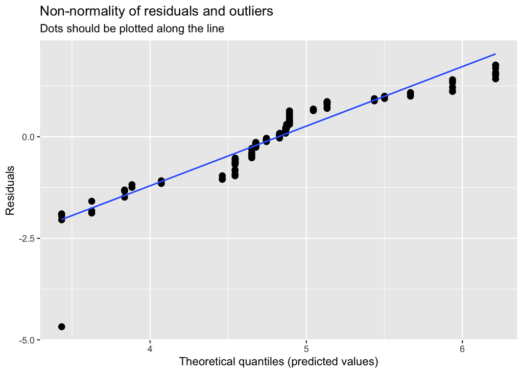

```r
plot_model(arch.random.model, type = "diag")[[1]]
```

*What proportion of the variation in species richness occurs at the archipelago scale, and what proportion occurs within archipelagos?*

```r
ranova(arch.random.model)
```

```
## ANOVA-like table for random-effects: Single term deletions
##
## Model:
## log(Species + 1) ~ (1 | Archipelago)
##                   npar  logLik    AIC    LRT Df Pr(>Chisq)
## <none>               3 -249.83 505.66
## (1 | Archipelago)    2 -263.17 530.33 26.677  1  2.405e-07 ***
## ---
## Signif. codes:  0 '***' 0.001 '**' 0.01 '*' 0.05 '.' 0.1 ' ' 1
```

*Which archipelagoes are particularly diverse, and which are depauperate?*

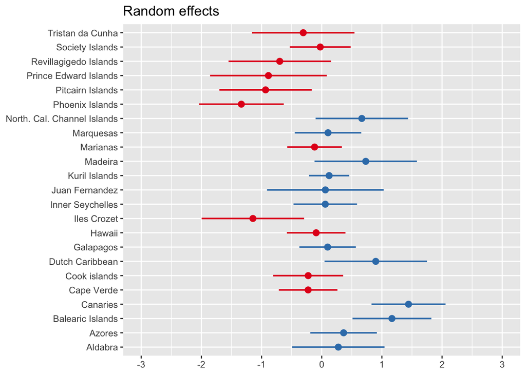

```r
plot_model(arch.random.model, type = "re")
```

```r
ranef(arch.random.model)
```

```
## $Archipelago
##                             (Intercept)
## Aldabra                      0.27580551
## Azores                       0.36364535
## Balearic Islands             1.16694684
## Canaries                     1.44291456
## Cape Verde                  -0.22577927
## Cook islands                -0.22480244
## Dutch Caribbean              0.89775039
## Galapagos                    0.09815643
## Hawaii                      -0.09271133
## Iles Crozet                 -1.14364253
## Inner Seychelles             0.05910589
## Juan Fernandez               0.06067849
## Kuril Islands                0.12305484
## Madeira                      0.73155849
## Marianas                    -0.11857937
## Marquesas                    0.10456242
## North. Cal. Channel Islands  0.66638146
## Phoenix Islands             -1.33611356
## Pitcairn Islands            -0.93311200
## Prince Edward Islands       -0.88584506
## Revillagigedo Islands       -0.69792449
## Society Islands             -0.02473534
## Tristan da Cunha            -0.30731528
##
## with conditional variances for "Archipelago"
```

*Make some exploratory plots of the effect of each variable on richness, plotted at the appropriate scale.*

```r
full <- merge(x = raw_isle, y = raw_arch, by = "Archipelago")%>%
  select(-c(2 , 7))
```

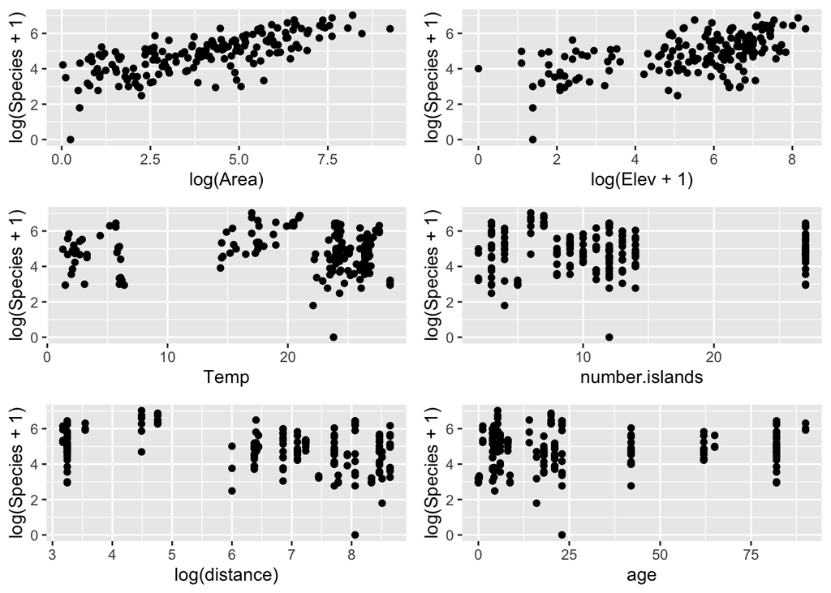

```r
grid.arrange(ggplot(full) + geom_point(aes(log(Area),log(Species+1))),#island
ggplot(full) + geom_point(aes(log(Elev+1), log(Species+1))),#island
ggplot(full) + geom_point(aes(Temp,log(Species+1))), #island
ggplot(full) + geom_point(aes(number.islands, log(Species+1))),#arch
ggplot(full) + geom_point(aes(log(distance), log(Species+1))),#arch
ggplot(full) + geom_point(aes(age, log(Species+1))),nrow = 3) #arch
```

```r
full$transspecies <- log(full$Species+1)
full$transarea <- log(full$Area)
full$transelev <- log(full$Elev+1)
full$transdist <- log(full$distance)
```

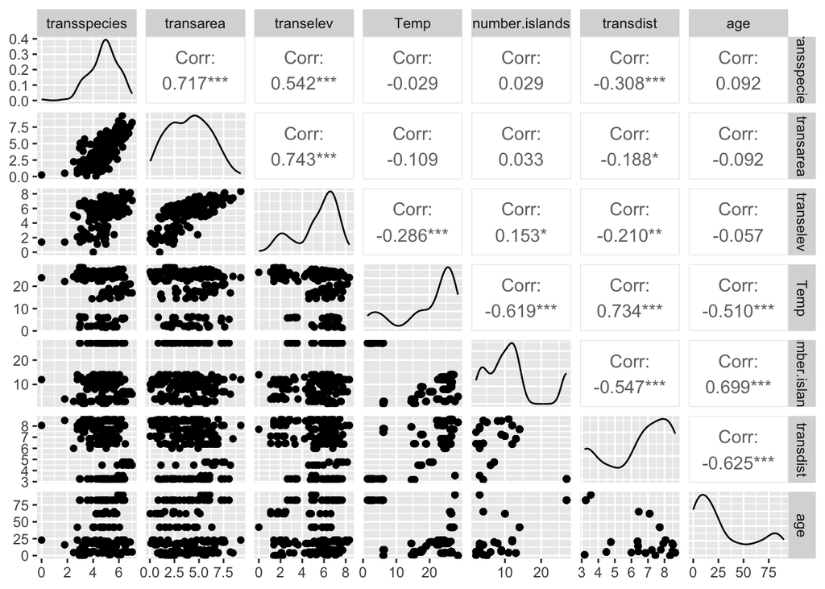

```r
ggpairs(full,columns = c("transspecies","transarea","transelev","Temp","number.islands","transdist","age"))
```

*Construct mixed model(s) that test the roles of the six predictors in explainingspecies richness.*

```r
no.fixed= lmer(transspecies~(1|Archipelago), data=full, REML = FALSE,na.action = na.pass)

no.interact = lmer(transspecies~(1|Archipelago)+transarea+transelev+Temp+transdist+age+number.islands, data=full, REML = FALSE,na.action = na.pass)

age.elev=lmer(transspecies~(1|Archipelago)+transarea+age*transelev+Temp+transdist+number.islands, data=full, REML = FALSE,na.action = na.pass) #I'm thinking maybe age of the island determines how diverse the species are by elevation

area.no.islands=lmer(transspecies~(1|Archipelago)+transarea*number.islands+age+transelev+Temp+transdist, data=full, REML = FALSE,na.action = na.pass)#I wanted to take number of islands out to see if that helps my power at all-- I don't really think it did the way I've done this, and I also think number of islands does have an effect on species diversity in an archipelago so it should be in the model somehow.


double.interact=lmer(transspecies~(1|Archipelago)+number.islands*transarea+age*transelev+Temp+transdist, data=full, REML = FALSE,na.action = na.pass)

#OK after thinking about this and trying a lot of different models I did not add because they felt like scratch paper, I think the effect of island area depends on how many islands are in the archipelago, and I think the effect of elevation depends on the age of the island.

double.random=lmer(transspecies~(1|Archipelago)+(transelev|age)+(transarea|number.islands)+Temp+transdist, data=full, REML = FALSE,na.action = na.pass)

summary(no.fixed)
```

```
## Linear mixed model fit by maximum likelihood . t-tests use Satterthwaite's
##   method [lmerModLmerTest]
## Formula: transspecies ~ (1 | Archipelago)
##    Data: full
##
##      AIC      BIC   logLik deviance df.resid
##    505.7    515.1   -249.8    499.7      171
##
## Scaled residuals:
##     Min      1Q  Median      3Q     Max
## -5.1489 -0.5376  0.0880  0.5816  1.9438
##
## Random effects:
##  Groups      Name        Variance Std.Dev.
##  Archipelago (Intercept) 0.6008   0.7751
##  Residual                0.8251   0.9083
## Number of obs: 174, groups:  Archipelago, 23
##
## Fixed effects:
##             Estimate Std. Error      df t value Pr(>|t|)
## (Intercept)   4.7697     0.1817 19.5567   26.25   <2e-16 ***
## ---
## Signif. codes:  0 '***' 0.001 '**' 0.01 '*' 0.05 '.' 0.1 ' ' 1
```

```r
summary(no.interact)
```

```
## Linear mixed model fit by maximum likelihood . t-tests use Satterthwaite's
##   method [lmerModLmerTest]
## Formula: transspecies ~ (1 | Archipelago) + transarea + transelev + Temp +
##     transdist + age + number.islands
##    Data: full
##
##      AIC      BIC   logLik deviance df.resid
##    319.0    347.5   -150.5    301.0      165
##
## Scaled residuals:
##     Min      1Q  Median      3Q     Max
## -5.5863 -0.5187  0.0658  0.5133  2.1074
##
## Random effects:
##  Groups      Name        Variance Std.Dev.
##  Archipelago (Intercept) 0.2774   0.5267
##  Residual                0.2519   0.5019
## Number of obs: 174, groups:  Archipelago, 23
##
## Fixed effects:
##                  Estimate Std. Error         df t value Pr(>|t|)
## (Intercept)     3.272e+00  6.569e-01  2.571e+01   4.982 3.63e-05 ***
## transarea       3.439e-01  3.261e-02  1.624e+02  10.547  < 2e-16 ***
## transelev       7.884e-02  3.967e-02  1.685e+02   1.987 0.048505 *
## Temp            7.613e-02  1.798e-02  2.886e+01   4.235 0.000212 ***
## transdist      -2.909e-01  8.418e-02  2.193e+01  -3.456 0.002259 **
## age             3.311e-03  5.638e-03  2.092e+01   0.587 0.563310
## number.islands  9.006e-04  2.311e-02  1.937e+01   0.039 0.969306
## ---
## Signif. codes:  0 '***' 0.001 '**' 0.01 '*' 0.05 '.' 0.1 ' ' 1
##
## Correlation of Fixed Effects:
##             (Intr) transr trnslv Temp   trnsds age
## transarea    0.058
## transelev   -0.277 -0.748
## Temp        -0.266 -0.199  0.240
## transdist   -0.711  0.112 -0.043 -0.391
## age         -0.366 -0.011  0.079 -0.210  0.442
## numbr.slnds -0.209  0.012 -0.041  0.147 -0.073 -0.411
```

```r
summary(age.elev)
```

```
## Linear mixed model fit by maximum likelihood . t-tests use Satterthwaite's
##   method [lmerModLmerTest]
## Formula: transspecies ~ (1 | Archipelago) + transarea + age * transelev +
##     Temp + transdist + number.islands
##    Data: full
##
##      AIC      BIC   logLik deviance df.resid
##    298.1    329.7   -139.1    278.1      164
##
## Scaled residuals:
##     Min      1Q  Median      3Q     Max
## -5.5947 -0.4341  0.1216  0.5305  2.2379
##
## Random effects:
##  Groups      Name        Variance Std.Dev.
##  Archipelago (Intercept) 0.2556   0.5056
##  Residual                0.2194   0.4684
## Number of obs: 174, groups:  Archipelago, 23
##
## Fixed effects:
##                  Estimate Std. Error         df t value Pr(>|t|)
## (Intercept)     2.344e+00  6.532e-01  3.161e+01   3.588 0.001110 **
## transarea       3.201e-01  3.086e-02  1.635e+02  10.372  < 2e-16 ***
## age             2.573e-02  7.046e-03  4.900e+01   3.652 0.000633 ***
## transelev       2.540e-01  5.126e-02  1.736e+02   4.954 1.71e-06 ***
## Temp            7.093e-02  1.716e-02  2.987e+01   4.135 0.000265 ***
## transdist      -2.747e-01  8.046e-02  2.306e+01  -3.414 0.002369 **
## number.islands  1.060e-02  2.218e-02  2.097e+01   0.478 0.637623
## age:transelev  -4.465e-03  9.018e-04  1.727e+02  -4.952 1.74e-06 ***
## ---
## Signif. codes:  0 '***' 0.001 '**' 0.01 '*' 0.05 '.' 0.1 ' ' 1
##
## Correlation of Fixed Effects:
##             (Intr) transr age    trnslv Temp   trnsds nmbr.s
## transarea    0.100
## age         -0.451 -0.109
## transelev   -0.385 -0.643  0.487
## Temp        -0.233 -0.184 -0.206  0.124
## transdist   -0.696  0.102  0.366 -0.001 -0.390
## numbr.slnds -0.225 -0.003 -0.256  0.031  0.139 -0.069
## age:translv  0.285  0.158 -0.645 -0.690  0.070 -0.044 -0.086
```

```r
summary(area.no.islands)
```

```
## Linear mixed model fit by maximum likelihood . t-tests use Satterthwaite's
##   method [lmerModLmerTest]
## Formula: transspecies ~ (1 | Archipelago) + transarea * number.islands +
##     age + transelev + Temp + transdist
##    Data: full
##
##      AIC      BIC   logLik deviance df.resid
##    320.9    352.5   -150.5    300.9      164
##
## Scaled residuals:
##     Min      1Q  Median      3Q     Max
## -5.5802 -0.4872  0.0719  0.5233  2.1234
##
## Random effects:
##  Groups      Name        Variance Std.Dev.
##  Archipelago (Intercept) 0.2790   0.5282
##  Residual                0.2515   0.5015
## Number of obs: 174, groups:  Archipelago, 23
##
## Fixed effects:
##                            Estimate Std. Error         df t value Pr(>|t|)
## (Intercept)                3.204461   0.686275  29.754050   4.669 6.02e-05 ***
## transarea                  0.358660   0.053745 163.843057   6.673 3.68e-10 ***
## number.islands             0.004985   0.025988  30.315025   0.192 0.849176
## age                        0.003338   0.005651  20.880689   0.591 0.561064
## transelev                  0.077203   0.039933 167.827378   1.933 0.054884 .
## Temp                       0.076048   0.018015  28.821446   4.221 0.000221 ***
## transdist                 -0.288092   0.084813  22.237863  -3.397 0.002563 **
## transarea:number.islands  -0.001007   0.002928 158.834219  -0.344 0.731434
## ---
## Signif. codes:  0 '***' 0.001 '**' 0.01 '*' 0.05 '.' 0.1 ' ' 1
##
## Correlation of Fixed Effects:
##             (Intr) transr nmbr.s age    trnslv Temp   trnsds
## transarea   -0.191
## numbr.slnds -0.307  0.367
## age         -0.356  0.009 -0.357
## transelev   -0.229 -0.545 -0.090  0.076
## Temp        -0.247 -0.143  0.118 -0.211  0.242
## transdist   -0.708  0.149 -0.018  0.441 -0.055 -0.391
## trnsr:nmbr.  0.283 -0.795 -0.454 -0.019  0.119  0.028 -0.103
```

```r
summary(double.interact)
```

```
## Linear mixed model fit by maximum likelihood . t-tests use Satterthwaite's
##   method [lmerModLmerTest]
## Formula: transspecies ~ (1 | Archipelago) + number.islands * transarea +
##     age * transelev + Temp + transdist
##    Data: full
##
##      AIC      BIC   logLik deviance df.resid
##    294.4    329.2   -136.2    272.4      163
##
## Scaled residuals:
##     Min      1Q  Median      3Q     Max
## -5.6587 -0.4674  0.1023  0.5782  2.3475
##
## Random effects:
##  Groups      Name        Variance Std.Dev.
##  Archipelago (Intercept) 0.2457   0.4956
##  Residual                0.2125   0.4610
## Number of obs: 174, groups:  Archipelago, 23
##
## Fixed effects:
##                            Estimate Std. Error         df t value Pr(>|t|)
## (Intercept)                2.590498   0.649229  33.452629   3.990 0.000340 ***
## number.islands            -0.016796   0.024553  33.088975  -0.684 0.498686
## transarea                  0.204995   0.056672 168.774424   3.617 0.000393 ***
## age                        0.031518   0.007326  55.848846   4.302 6.87e-05 ***
## transelev                  0.313129   0.056122 173.973786   5.579 9.10e-08 ***
## Temp                       0.070608   0.016838  30.168486   4.193 0.000222 ***
## transdist                 -0.292099   0.079270  23.873982  -3.685 0.001171 **
## number.islands:transarea   0.007434   0.003092 164.310440   2.404 0.017324 *
## age:transelev             -0.005669   0.001019 173.860220  -5.564 9.79e-08 ***
## ---
## Signif. codes:  0 '***' 0.001 '**' 0.01 '*' 0.05 '.' 0.1 ' ' 1
##
## Correlation of Fixed Effects:
##             (Intr) nmbr.s transr age    trnslv Temp   trnsds nmbr.:
## numbr.slnds -0.270
## transarea   -0.080  0.390
## age         -0.370 -0.366 -0.333
## transelev   -0.274 -0.179 -0.680  0.559
## Temp        -0.231  0.126 -0.093 -0.197  0.109
## transdist   -0.699 -0.018  0.132  0.314 -0.041 -0.388
## nmbr.slnds:  0.158 -0.464 -0.844  0.328  0.439 -0.007 -0.092
## age:translv  0.168  0.161  0.488 -0.693 -0.756  0.064  0.007 -0.491
```

```r
summary(double.random) #this looks like it sucks
```

```
## Linear mixed model fit by maximum likelihood . t-tests use Satterthwaite's
##   method [lmerModLmerTest]
## Formula: transspecies ~ (1 | Archipelago) + (transelev | age) + (transarea |
##     number.islands) + Temp + transdist
##    Data: full
##
##      AIC      BIC   logLik deviance df.resid
##    332.5    367.3   -155.3    310.5      163
##
## Scaled residuals:
##     Min      1Q  Median      3Q     Max
## -4.6824 -0.3493  0.1274  0.4498  2.7123
##
## Random effects:
##  Groups         Name        Variance Std.Dev. Corr
##  Archipelago    (Intercept) 0.00000  0.0000
##  age            (Intercept) 4.21027  2.0519
##                 transelev   0.09457  0.3075   -0.97
##  number.islands (Intercept) 1.66577  1.2906
##                 transarea   0.09233  0.3039   -1.00
##  Residual                   0.18084  0.4253
## Number of obs: 174, groups:  Archipelago, 23; age, 21; number.islands, 14
##
## Fixed effects:
##             Estimate Std. Error       df t value Pr(>|t|)
## (Intercept)  5.44797    0.46998 26.48828  11.592 7.03e-12 ***
## Temp         0.06920    0.01579 30.48324   4.383 0.000128 ***
## transdist   -0.27730    0.07779 24.00085  -3.565 0.001568 **
## ---
## Signif. codes:  0 '***' 0.001 '**' 0.01 '*' 0.05 '.' 0.1 ' ' 1
##
## Correlation of Fixed Effects:
##           (Intr) Temp
## Temp      -0.124
## transdist -0.772 -0.488
## optimizer (nloptwrap) convergence code: 0 (OK)
## boundary (singular) fit: see help('isSingular')
```

The double random doesn’t look that good. The double interaction model does the best and makes the most sense to me I think, so I will go with this one.

*Plot fitted (fixed) effects as well as random effect estimates, plus model diagnostics.*

fitted

```r
fixef(double.interact)
```

```
##              (Intercept)           number.islands                transarea
##              2.590498015             -0.016796421              0.204994644
##                      age                transelev                     Temp
##              0.031517798              0.313129382              0.070608066
##                transdist number.islands:transarea            age:transelev
##             -0.292098617              0.007433508             -0.005668689
```

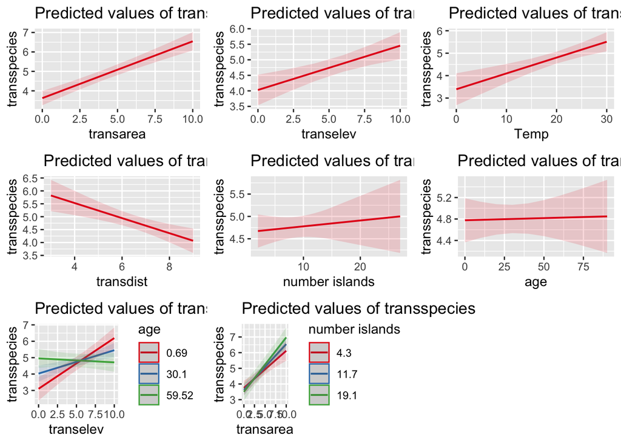

```r
grid.arrange(plot_model(double.interact, type = "eff", terms = c('transarea')),
plot_model(double.interact, type = "eff", terms = c('transelev')),
plot_model(double.interact, type = "eff", terms = c('Temp')),
plot_model(double.interact, type = "eff", terms = c('transdist')),
plot_model(double.interact, type = "eff", terms = c('number.islands')),
plot_model(double.interact, type = "eff", terms = c('age')),
plot_model(double.interact, type = "eff", terms = c('transelev','age')),
plot_model(double.interact, type = "eff", terms = c('transarea','number.islands')))
```

Random

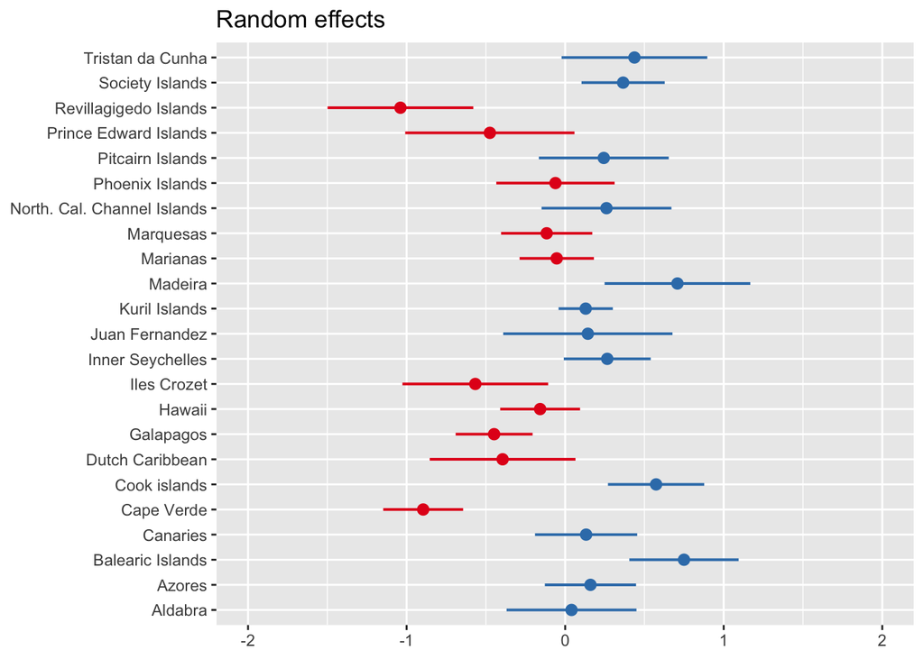

```r
plot_model(double.interact, type = "re")
```

Diagnostics: Random

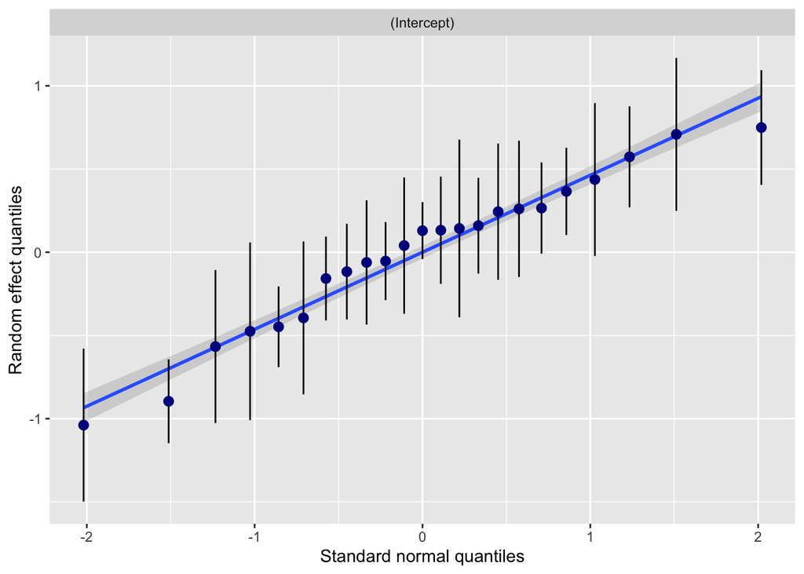

```r
plot_model(double.interact, type = "diag")[[2]]
```

```r
VarCorr(double.interact)
```

```
##  Groups      Name        Std.Dev.
##  Archipelago (Intercept) 0.49564
##  Residual                0.46102
```

Diagnostics: Fixed

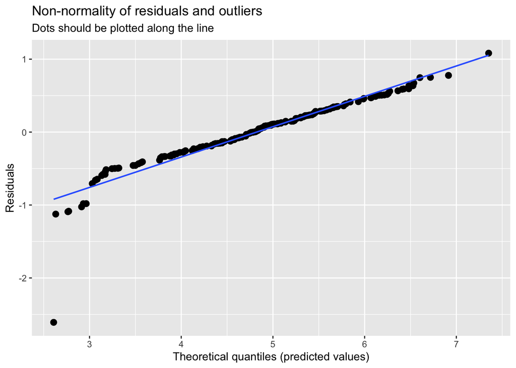

```r
plot_model(double.interact, type = "diag")[[1]]
```

*Calculate how much variation the predictors explain, at the two different scales in the data (island and archipelago)? I.e., present R2 values for the two scales.*

```r
island =lmer(transspecies~(1|Archipelago)+transelev+transarea+Temp, data=full, REML = FALSE,na.action = na.pass)
arch =lmer(transspecies~(1|Archipelago)+age+number.islands+transdist, data=full, REML = FALSE,na.action = na.pass)

VarCorr(island)
```

```
##  Groups      Name        Std.Dev.
##  Archipelago (Intercept) 0.73651
##  Residual                0.50247
```

```r
VarCorr(arch)
```

```
##  Groups      Name        Std.Dev.
##  Archipelago (Intercept) 0.56340
##  Residual                0.90725
```

```r
1 - VarCorr(arch)$Archipelago[1]/VarCorr(island)$Archipelago[1]
```

```
## [1] 0.4148476
```

*Also, how much of the total variation have they explained, according to R2 GLMM(m)?*

```r
r.squaredGLMM(island)
```

```
##            R2m       R2c
## [1,] 0.5262007 0.8495152
```

```r
r.squaredGLMM(arch)
```

```
##            R2m       R2c
## [1,] 0.2188569 0.4362567
```

Here’s the ones for my actual model though, where I combined both scales?

```r
VarCorr(no.fixed)
```

```
##  Groups      Name        Std.Dev.
##  Archipelago (Intercept) 0.77510
##  Residual                0.90833
```

```r
VarCorr(no.interact)
```

```
##  Groups      Name        Std.Dev.
##  Archipelago (Intercept) 0.52669
##  Residual                0.50188
```

```r
VarCorr(double.interact)
```

```
##  Groups      Name        Std.Dev.
##  Archipelago (Intercept) 0.49564
##  Residual                0.46102
```

```r
#it looks like the unexplained variation goes down as I add my fixed effects and interactions.


1 - VarCorr(no.interact)$Archipelago[1]/VarCorr(no.fixed)$Archipelago[1]
```

```
## [1] 0.5382617
```

```r
r.squaredGLMM(double.interact)
```

```
##            R2m       R2c
## [1,] 0.6823607 0.8526587
```

*Use appropriate hypothesis tests (as described in lecture) to test the role of the different predictors.*

I would really think all of these predictors are important, so I don’t really want to test them individually– hopefully this works ok!

```r
anova(no.interact,age.elev)
```

```
## Data: full
## Models:
## no.interact: transspecies ~ (1 | Archipelago) + transarea + transelev + Temp + transdist + age + number.islands
## age.elev: transspecies ~ (1 | Archipelago) + transarea + age * transelev + Temp + transdist + number.islands
##             npar    AIC    BIC  logLik deviance  Chisq Df Pr(>Chisq)
## no.interact    9 319.02 347.45 -150.51   301.02
## age.elev      10 298.10 329.69 -139.05   278.10 22.919  1   1.69e-06 ***
## ---
## Signif. codes:  0 '***' 0.001 '**' 0.01 '*' 0.05 '.' 0.1 ' ' 1
```

```r
anova(no.interact,area.no.islands)
```

```
## Data: full
## Models:
## no.interact: transspecies ~ (1 | Archipelago) + transarea + transelev + Temp + transdist + age + number.islands
## area.no.islands: transspecies ~ (1 | Archipelago) + transarea * number.islands + age + transelev + Temp + transdist
##                 npar    AIC    BIC  logLik deviance  Chisq Df Pr(>Chisq)
## no.interact        9 319.02 347.45 -150.51   301.02
## area.no.islands   10 320.90 352.49 -150.45   300.90 0.1179  1     0.7314
```

```r
anova(age.elev,double.interact)
```

```
## Data: full
## Models:
## age.elev: transspecies ~ (1 | Archipelago) + transarea + age * transelev + Temp + transdist + number.islands
## double.interact: transspecies ~ (1 | Archipelago) + number.islands * transarea + age * transelev + Temp + transdist
##                 npar    AIC    BIC  logLik deviance  Chisq Df Pr(>Chisq)
## age.elev          10 298.10 329.69 -139.05   278.10
## double.interact   11 294.42 329.16 -136.21   272.42 5.6854  1    0.01711 *
## ---
## Signif. codes:  0 '***' 0.001 '**' 0.01 '*' 0.05 '.' 0.1 ' ' 1
```

```r
anova(no.interact,double.interact)
```

```
## Data: full
## Models:
## no.interact: transspecies ~ (1 | Archipelago) + transarea + transelev + Temp + transdist + age + number.islands
## double.interact: transspecies ~ (1 | Archipelago) + number.islands * transarea + age * transelev + Temp + transdist
##                 npar    AIC    BIC  logLik deviance  Chisq Df Pr(>Chisq)
## no.interact        9 319.02 347.45 -150.51   301.02
## double.interact   11 294.42 329.16 -136.21   272.42 28.604  2  6.147e-07 ***
## ---
## Signif. codes:  0 '***' 0.001 '**' 0.01 '*' 0.05 '.' 0.1 ' ' 1
```

```r
anovaresults <- anova(double.interact, type=2)
anovaresults
```

```
## Type II Analysis of Variance Table with Satterthwaite's method
##                          Sum Sq Mean Sq NumDF   DenDF F value    Pr(>F)
## number.islands           0.0995  0.0995     1  33.089  0.4680 0.4986862
## transarea                2.7809  2.7809     1 168.774 13.0841 0.0003931 ***
## age                      3.9338  3.9338     1  55.849 18.5082 6.869e-05 ***
## transelev                6.6163  6.6163     1 173.974 31.1296 9.099e-08 ***
## Temp                     3.7376  3.7376     1  30.168 17.5852 0.0002219 ***
## transdist                2.8859  2.8859     1  23.874 13.5781 0.0011710 **
## number.islands:transarea 1.2284  1.2284     1 164.310  5.7798 0.0173244 *
## age:transelev            6.5809  6.5809     1 173.860 30.9629 9.795e-08 ***
## ---
## Signif. codes:  0 '***' 0.001 '**' 0.01 '*' 0.05 '.' 0.1 ' ' 1
```

*What are the denominator degrees of freedom for each predictor?*

```r
den_df <- anovaresults$DenDF
den_df
```

```
## [1]  33.08897 168.77442  55.84885 173.97379  30.16849  23.87398 164.31044
## [8] 173.86022
```

*Do the denominator df make sense? Why or why not?* Most of them do! The island predictors like area, elevation, and the two interactions are close to the max number of island samples, 174.

number of islands and the distance from other land also looks… eh, okay? distance definitely does. That is because they are close to the Archipelago sample size, which is 23.

Temperature and age are a little wonky since they are not close to the island or archipeligo. I think Age could be because of partial pooling, maybe? They both might be because the same age number is assigned to multiple islands. Temperature is assigned by island, but the same numbers repeat a lot. That could be an issue?

*Is the model we’ve used the best model? Often I just stick with one big model when the ratio of data to parameters is pretty good. But one might prefer to find the best model(s), while accounting for model selection uncertainty.*

I think this is the best model I can come up with right -now-, but I don’t know if that is saying much ya know

*Use AICc in some capacity to assess which predictors are important, what the ‘best’ model is, and how sure you are about what the best model is.*

Iʻd like to see if dredging comes up with the same thing I picked:

```r
full.dredge = dredge(double.interact, extra = "R^2")
full.dredge
```

```
## Global model call: lmer(formula = transspecies ~ (1 | Archipelago) + number.islands *
##     transarea + age * transelev + Temp + transdist, data = full,
##     REML = FALSE, na.action = na.pass)
## ---
## Model selection table
##       (Int)        age    nmb.isl     Tmp  trnsr   trnsd   trnsl age:trnsl
## 256  2.5900  3.152e-02 -0.0168000 0.07061 0.2050 -0.2921 0.31310 -0.005669
## 126  2.4130  2.659e-02            0.06982 0.3201 -0.2721 0.25320 -0.004429
## 128  2.3440  2.573e-02  0.0106000 0.07093 0.3201 -0.2747 0.25400 -0.004465
## 240  0.8123  4.029e-02 -0.0180400 0.05082 0.2259         0.31090 -0.005721
## 110  0.7357  3.496e-02            0.05196 0.3291         0.25610 -0.004594
## 112  0.6849  3.444e-02  0.0066600 0.05247 0.3291         0.25640 -0.004610
## 252  3.1530  3.849e-02 -0.0284600         0.2229 -0.1647 0.30040 -0.006076
## 236  1.9060  4.313e-02 -0.0276500         0.2295         0.30400 -0.006067
## 122  2.9110  3.233e-02                    0.3414 -0.1461 0.23750 -0.004817
```

[output cut: 195 more lines]